# The following code snippets go over some of the fundamental features of FDSN-via-ObsPy

Requirements :

-A working internet connection

-Python3 (2.7 may also work but not recommended) & and interactive interpreter (e.g. ipython3)

-ObsPy installed. Use a package manager (such as conda or pip) to install all dependencies (numpy, SQLAlchemy, lxml, Cython, future, proj4, matplotlib and cartopy or basemap). For detailed instructions to install ObsPy, go to https://www.obspy.org/.

At its simplest, obspy can be used in a manner equivalent to curl or wget (or a web browser!) to grab miniseed data via a single target, similar to pointing to a file

| Element | Signification |
| --- | --- |
| ? | marks the end of the website adress serving the data |
| & | separates the arguments to select AusPass data |
| http://auspass.edu.au:80/ | Client name (AusPass website serving data on port 80) |
| fdsnws/ | FSDN Web Services on that client |
| dataselect/1/ | Data retrieval services (distinct for station metadata and event metadata) |
| query | Do a download |
| net=S1 | Seismic network "S1" - AUstralian Seismometers In Schools - AUSIS |
| sta=AUAYR | Station "AUAYR" located at Ayr, Queensland, Australia |
| cha=BH? | All broadband channels available starting with "BH" ie. BHE, BHN and BHZ |
| start=2018-03-29T20:00:00.000 | Data start time using ISO standard date and time format |
| end=2018-03-29T20:10:00.000 | Data end time using ISO standard date and time format |

```
3 Trace(s) in Stream:
S1.AUAYR..BHZ | 2018-03-29T19:59:41.000000Z - 2018-03-29T20:10:01.500000Z | 10.0 Hz, 6206 samples
S1.AUAYR..BHE | 2018-03-29T19:59:48.000000Z - 2018-03-29T20:10:13.800000Z | 10.0 Hz, 6259 samples
S1.AUAYR..BHN | 2018-03-29T19:59:57.800000Z - 2018-03-29T20:10:00.900000Z | 10.0 Hz, 6032 samples
```

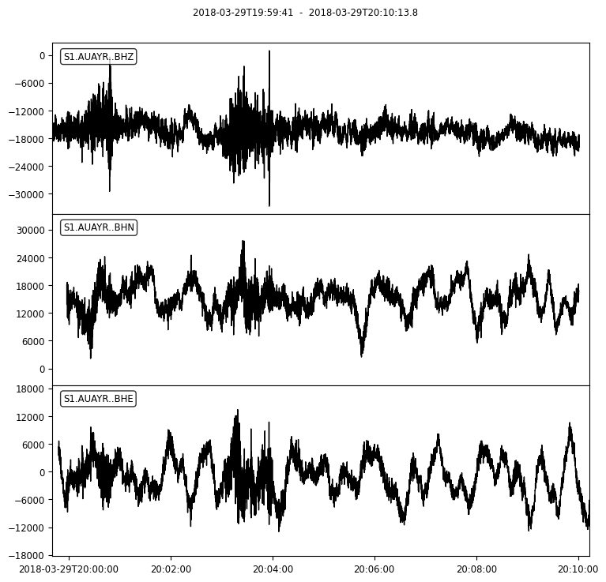

```python
# a very simple version which grabs data using the above elements pasted together

import obspy
from matplotlib import pyplot as plt
st = obspy.read('http://auspass.edu.au:80/fdsnws/dataselect/1/query?net=S1&sta=AUAYR&cha=BH?&start=2018-03-29T20:00:00.000&end=2018-03-29T20:10:00.000')
print(st)
st.plot(); plt.close() #note that "plt.close()" may not be necessary for you!
```

## However the true utility of this protocol is its use in a modular or object-oriented sense. Let's try again.

# Establish an FDSN connection

- User_agent field is not required, but it is polite to include and allows us to contact you in the unlikely event your requests are causing an issue. Your address is not stored or added to any lists.
- User and password should ONLY be given here if you are requesting restricted data. Restricted data is typically limited to the PI for up to 2 years following its availability here.

```python
import obspy
from obspy.clients.fdsn import Client as FDSN_Client
from matplotlib import pyplot as plt
auspass = FDSN_Client('http://auspass.edu.au:8080',user_agent='email@address.com') #,user='username',password='password')
```

# Set request parameters

```python
network = "S1"
station = "AUAYR"
location = "*" #n.b. AusPass data typically has a univeral blank (e.g. '') value for ALL station locations. "*" works just as well.
channel = "BH*" #note that BH* channels here are 10 Hz, HH* are 100
time0 = obspy.UTCDateTime(2018,3,29,1,19,5) #1 hour, 19 minutes, and 5 seconds after start of March 29 2018 (UTC)
time1 = time0 + 180 #180 seconds after time0
```